# Fragilidad bancaria, riesgo de cola del crecimiento y spread soberano

Triangulación en tres bases — LatAm corta, LatAm larga y panel extendido a 15 países

Mauricio

17/07/2026

# 1 Objetivo y convenciones

`Regresiones_panel.Rmd` estimaba la especificación central en **una** base (núcleo LatAm, 2010Q1-2022Q2). Este documento la reestima en **tres** bases para ver si la complementariedad JLoss × GaR sobrevive tanto a una ventana temporal más larga del núcleo LatAm como a la extensión a países fuera de LatAm:

1. **LatAm corta** (`Panel_final_prebackup.csv`) — la base original: 5 países, 2010Q1-2022Q2, GaR construido con la plataforma CEMLA/`GaR_test.xlsx`.
2. **LatAm larga** (`Panel_final.csv`) — mismos 5 países, mismo EMBI real (BCRP) y mismo JLoss, pero GaR reconstruido con el panel de 15 países (`gar_panel_all15.csv`), que tiene más historia de entrenamiento y extiende la ventana a **2007Q4**. Mismos controles domésticos (`controls_panel.csv`) y VIX/g_GDP que la corta, más el parche de deuda de Chile (BCCh).
3. **Panel extendido** (`Panel_extended_15paises.csv`) — agrega Bulgaria, China, Indonesia, Polonia, Sudáfrica y Turquía con EMBI **real** (no proxy): BCRP para los 5 LatAm, tablas del *Global Financial Stability Report* del FMI (2011-2015) para los otros 6. **Sin controles domésticos** (no hay `debt_gdp`/`fisc_bal`/etc. para estos 6 países) y con **VIX global CBOE** en vez del VIX/g_GDP de la plataforma CEMLA.

Especificación central (igual en las tres bases):

$$EMBI_{i,t}=\alpha_i+\lambda_t+\beta_1
JLoss_{i,t}+\beta_2 GaR_{i,t}+\theta\,(JLoss\times
GaR)_{i,t}+\gamma' X_{i,t}+\varepsilon_{i,t}$$

**Decisiones metodológicas heredadas de `Regresiones_panel.Rmd` (sin cambios):**

- **Errores estándar Driscoll-Kraay** (`vcovSCC`), robustos a heterocedasticidad, autocorrelación y dependencia transversal.
- **`GaR` en puntos porcentuales** (×100).
- **Variables clave centradas** (`_c`).
- **No se incluye `g_GDP`/media de crecimiento junto a `GaR`** (colinealidad severa, mismo argumento que la base corta).

**Advertencia que aplica solo al panel extendido** (sección 4): varios países nuevos aportan **T muy corto** (Sudáfrica *n*=6, Bulgaria *n*=16) y **fuera del rango 2010Q1-2014Q4 el panel vuelve a ser esencialmente el núcleo LatAm** (ver el diagnóstico de cobertura más abajo). Driscoll-Kraay asume *T* moderado/grande por unidad; con countries de *T*=6-20 esa asintótica es débil. Todo lo que sigue en la sección 4 debe leerse como **evidencia exploratoria complementaria**, no como un reemplazo de la estimación LatAm.

# 2 Paquetes y carga de las tres bases

```r
# install.packages(c("plm","lmtest","sandwich","modelsummary","fixest",
#                    "ggplot2","dplyr","car","kableExtra","tidyr"))
library(plm)
library(lmtest)
library(sandwich)
library(modelsummary)
library(ggplot2)
library(dplyr)
library(tidyr)
library(car)
library(kableExtra)

prep <- function(path) {
  d <- read.csv(path, stringsAsFactors = FALSE)
  d$year <- as.integer(substr(d$quarter, 1, 4))
  d$q    <- as.integer(substr(d$quarter, 6, 6))
  d$tnum <- d$year + (d$q - 1) / 4
  d <- d[order(d$country, d$tnum), ]
  d$GaR_pp <- d$GaR * 100
  d$ES_pp  <- if ("ES" %in% names(d)) d$ES * 100 else NA
  center <- function(x) x - mean(x, na.rm = TRUE)
  d$JLoss_c <- center(d$JLoss)
  d$GaR_c   <- center(d$GaR_pp)
  d$JxG_c   <- d$JLoss_c * d$GaR_c
  d$lnEMBI  <- log(d$EMBI_bps)
  d$post2020 <- as.integer(d$year >= 2020)
  d
}

corta    <- prep("Panel_final_prebackup.csv")
larga    <- prep("Panel_final.csv")
extendida<- prep("Panel_extended_15paises.csv")

pan_corta    <- pdata.frame(corta,     index = c("country", "tnum"))
pan_larga    <- pdata.frame(larga,     index = c("country", "tnum"))
pan_ext      <- pdata.frame(extendida, index = c("country", "tnum"))

DK <- function(m) vcovSCC(m, type = "HC1", maxlag = NULL)
```

```r
cov <- bind_rows(
  corta     %>% mutate(base = "1. LatAm corta"),
  larga     %>% mutate(base = "2. LatAm larga"),
  extendida %>% mutate(base = "3. Extendida 15 países")
) %>%
  group_by(base, country) %>%
  summarise(n = n(), desde = min(quarter), hasta = max(quarter), .groups = "drop")

kable(cov, caption = "Cobertura por base y país") %>%
  kable_styling(full_width = FALSE, font_size = 12)
```

Cobertura por base y país

base

country

n

desde

hasta

1. LatAm corta

brazil

50

2010Q1

2022Q2

1. LatAm corta

chile

48

2010Q1

2021Q4

1. LatAm corta

colombia

50

2010Q1

2022Q2

1. LatAm corta

mexico

50

2010Q1

2022Q2

1. LatAm corta

peru

50

2010Q1

2022Q2

2. LatAm larga

brazil

59

2007Q4

2022Q2

2. LatAm larga

chile

57

2007Q4

2021Q4

2. LatAm larga

colombia

59

2007Q4

2022Q2

2. LatAm larga

mexico

59

2007Q4

2022Q2

2. LatAm larga

peru

59

2007Q4

2022Q2

3. Extendida 15 países

brazil

59

2007Q4

2022Q2

3. Extendida 15 países

bulgaria

16

2010Q1

2013Q4

3. Extendida 15 países

chile

57

2007Q4

2021Q4

3. Extendida 15 países

china

20

2010Q1

2014Q4

3. Extendida 15 países

colombia

59

2007Q4

2022Q2

3. Extendida 15 países

indonesia

20

2010Q1

2014Q4

3. Extendida 15 países

mexico

59

2007Q4

2022Q2

3. Extendida 15 países

peru

59

2007Q4

2022Q2

3. Extendida 15 países

poland

20

2010Q1

2014Q4

3. Extendida 15 países

southafrica

6

2010Q1

2011Q2

3. Extendida 15 países

turkey

20

2010Q1

2014Q4

```r
# GaR viene NA en los primeros trimestres de entrenamiento de cada país
# (n_train insuficiente para la regresión cuantílica) y desaparece de las
# regresiones vía na.omit. Se reporta la cobertura EFECTIVA (GaR no-NA),
# no solo la cobertura de filas del CSV.
eff <- bind_rows(
  corta     %>% mutate(base = "1. LatAm corta"),
  larga     %>% mutate(base = "2. LatAm larga"),
  extendida %>% mutate(base = "3. Extendida 15 países")
) %>%
  group_by(base, country) %>%
  summarise(n_filas = n(), n_GaR_valido = sum(!is.na(GaR)), .groups = "drop") %>%
  filter(n_filas != n_GaR_valido)

if (nrow(eff) > 0) {
  kable(eff, caption = "Filas con GaR faltante (excluidas automáticamente de las regresiones vía na.omit)") %>%
    kable_styling(full_width = FALSE, font_size = 12)
} else {
  cat("Sin filas con GaR faltante en ninguna base.\n")
}
```

Filas con GaR faltante (excluidas automáticamente de las regresiones vía na.omit)

base

country

n_filas

n_GaR_valido

2. LatAm larga

colombia

59

55

2. LatAm larga

peru

59

51

3. Extendida 15 países

bulgaria

16

8

3. Extendida 15 países

colombia

59

55

3. Extendida 15 países

peru

59

51

3. Extendida 15 países

turkey

20

19

> **Nota de cobertura efectiva.** Bulgaria pierde la mitad de sus 16 trimestres nominales (2010Q1-2011Q4 sin GaR entrenado), quedando con ~8 observaciones utilizables en la sección 4 — trátese como anecdótico, no como evidencia con poder estadístico. Colombia y Perú en la base larga arrancan de forma efectiva un poco después de 2007Q4 por el mismo motivo (n_train insuficiente al inicio de la ventana).

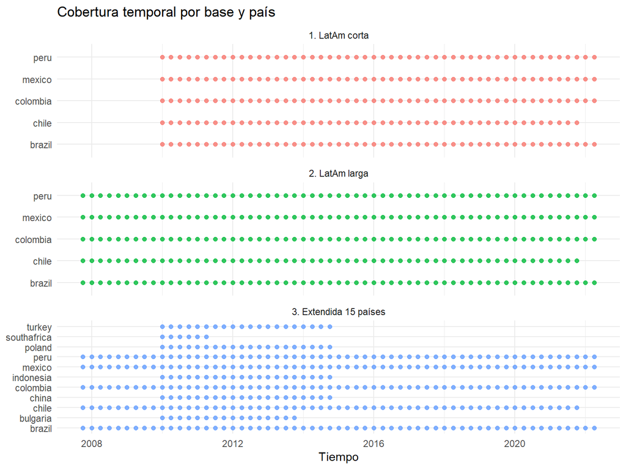

```r
covp <- bind_rows(
  corta     %>% mutate(base = "1. LatAm corta"),
  larga     %>% mutate(base = "2. LatAm larga"),
  extendida %>% mutate(base = "3. Extendida 15 países")
)
ggplot(covp, aes(x = tnum, y = country, color = base)) +
  geom_point(size = 1.6, alpha = .8) +
  facet_wrap(~base, ncol = 1, scales = "free_y") +
  labs(x = "Tiempo", y = NULL, title = "Cobertura temporal por base y país") +
  theme_minimal(base_size = 11) +
  theme(legend.position = "none")
```

> **Lectura del gráfico de cobertura.** La base larga estira el núcleo LatAm ~9 trimestres hacia atrás (2007Q4 vs 2010Q1) gracias al panel GaR de 15 países. La base extendida agrega países, pero casi todos viven exclusivamente en la ventana 2010Q1-2014Q4 (excepto los 5 LatAm, que corren en toda la ventana). Esto se explota en la sección 4.2 con una especificación restringida a esa ventana común.

# 3 Sección 1 — Núcleo LatAm: corta vs. larga

```r
run_main <- function(pdat, dat) {
  ctrl <- "debt_gdp + fisc_bal + res_gdp + ca_gdp + infl_yoy + reer"
  list(
    M1 = plm(EMBI_bps ~ JLoss_c + GaR_c, data = pdat, model = "within", effect = "twoways"),
    M2 = plm(EMBI_bps ~ JLoss_c + GaR_c + JxG_c, data = pdat, model = "within", effect = "twoways"),
    M3 = plm(as.formula(paste("EMBI_bps ~ JLoss_c + GaR_c + JxG_c +", ctrl)),
             data = pdat, model = "within", effect = "twoways"),
    M4 = plm(as.formula(paste("lnEMBI ~ JLoss_c + GaR_c + JxG_c +", ctrl)),
             data = pdat, model = "within", effect = "twoways"),
    M5 = plm(as.formula(paste("EMBI_bps ~ JLoss_c + GaR_c + JxG_c + VIX +", ctrl)),
             data = pdat, model = "within", effect = "individual")
  )
}

mods_corta <- run_main(pan_corta, corta)
mods_larga <- run_main(pan_larga, larga)

cmap <- c("JLoss_c"="JLoss", "GaR_c"="GaR (pp)", "JxG_c"="JLoss × GaR", "VIX"="VIX",
          "debt_gdp"="Deuda/PIB", "fisc_bal"="Balance fiscal/PIB",
          "res_gdp"="Reservas/PIB", "ca_gdp"="Cuenta corriente/PIB",
          "infl_yoy"="Inflación YoY", "reer"="REER")

todos_latam <- c(setNames(mods_corta, paste0("Corta ", names(mods_corta))),
                  setNames(mods_larga, paste0("Larga ", names(mods_larga))))

modelsummary(todos_latam,
  vcov = lapply(todos_latam, DK),
  coef_map = cmap,
  stars = c('*'=.1,'**'=.05,'***'=.01),
  gof_omit = "AIC|BIC|Log.Lik|RMSE|Adj",
  notes = "SE Driscoll-Kraay. M1-M4: FE país+tiempo. M5: FE país + VIX explícito.",
  title = "Tabla 1. Núcleo LatAm — corta (2010Q1-2022Q2) vs. larga (2007Q4-2022Q2)")
```

Tabla 1. Núcleo LatAm — corta (2010Q1-2022Q2) vs. larga (2007Q4-2022Q2)

|  | Corta M1 | Corta M2 | Corta M3 | Corta M4 | Corta M5 | Larga M1 | Larga M2 | Larga M3 | Larga M4 | Larga M5 |
| --- | --- | --- | --- | --- | --- | --- | --- | --- | --- | --- |
| JLoss | 2.731*** | 1.233*** | 1.340* | 0.007*** | 0.171 | 2.261*** | 1.271*** | 1.580*** | 0.006*** | 0.605 |
|  | (0.571) | (0.427) | (0.680) | (0.002) | (0.805) | (0.637) | (0.464) | (0.506) | (0.002) | (0.576) |
| GaR (pp) | 3.423* | 2.863 | 1.663 | 0.009 | -4.408** | 1.712 | 1.558 | 0.893 | 0.004 | -5.056** |
|  | (2.057) | (2.086) | (2.846) | (0.009) | (2.170) | (2.739) | (2.615) | (2.194) | (0.008) | (2.180) |
| JLoss × GaR |  | -0.352*** | -0.316*** | -0.000 | -0.223* |  | -0.336*** | -0.305** | -0.000 | -0.226* |
|  |  | (0.089) | (0.102) | (0.000) | (0.119) |  | (0.120) | (0.138) | (0.000) | (0.129) |
| VIX |  |  |  |  | 4.112 |  |  |  |  | 1.633 |
|  |  |  |  |  | (3.717) |  |  |  |  | (3.966) |
| Deuda/PIB |  |  | -2.062*** | -0.006** | -1.857*** |  |  | -1.334 | -0.003 | -1.190* |
|  |  |  | (0.670) | (0.002) | (0.628) |  |  | (0.837) | (0.003) | (0.622) |
| Balance fiscal/PIB |  |  | 7.703* | 0.025* | 2.329 |  |  | 6.775 | 0.021 | 2.552 |
|  |  |  | (4.357) | (0.013) | (3.306) |  |  | (4.221) | (0.013) | (2.946) |
| Reservas/PIB |  |  | 6.858** | 0.027** | 3.695* |  |  | 2.852 | 0.012 | 3.380** |
|  |  |  | (2.878) | (0.011) | (2.001) |  |  | (2.714) | (0.011) | (1.630) |
| Cuenta corriente/PIB |  |  | 10.770* | 0.017 | 12.832*** |  |  | 4.173* | 0.006 | 6.388*** |
|  |  |  | (6.135) | (0.022) | (3.638) |  |  | (2.339) | (0.009) | (2.211) |
| Inflación YoY |  |  | -4.502 | -0.011 | 8.332** |  |  | -1.540 | 0.001 | 7.762*** |
|  |  |  | (6.273) | (0.022) | (3.711) |  |  | (4.570) | (0.016) | (2.518) |
| REER |  |  | -1.070*** | -0.004*** | -2.245*** |  |  | -1.089*** | -0.005*** | -1.997*** |
|  |  |  | (0.355) | (0.001) | (0.432) |  |  | (0.261) | (0.001) | (0.356) |
| Num.Obs. | 248 | 248 | 200 | 200 | 200 | 281 | 281 | 253 | 253 | 253 |
| R2 | 0.131 | 0.165 | 0.447 | 0.404 | 0.641 | 0.091 | 0.116 | 0.418 | 0.361 | 0.612 |
| Std.Errors | Corta M1 | Corta M2 | Corta M3 | Corta M4 | Corta M5 | Larga M1 | Larga M2 | Larga M3 | Larga M4 | Larga M5 |

* p < 0.1, ** p < 0.05, *** p < 0.01  
SE Driscoll-Kraay. M1-M4: FE país+tiempo. M5: FE país + VIX explícito.

> **Qué mirar primero.** El coeficiente que importa es $\theta$ (`JLoss × GaR`) en M2-M5. Si el signo y la significancia se mantienen entre “Corta” y “Larga”, la ventana adicional de 2007Q4 a 2009Q4 (crisis financiera global incluida) no está impulsando el resultado artificialmente ni tampoco lo está disolviendo — es la forma más directa de auditar si “hacer más robusto el GaR” cambia la conclusión.

## 3.2 Efecto marginal de JLoss según severidad de GaR — corta vs. larga

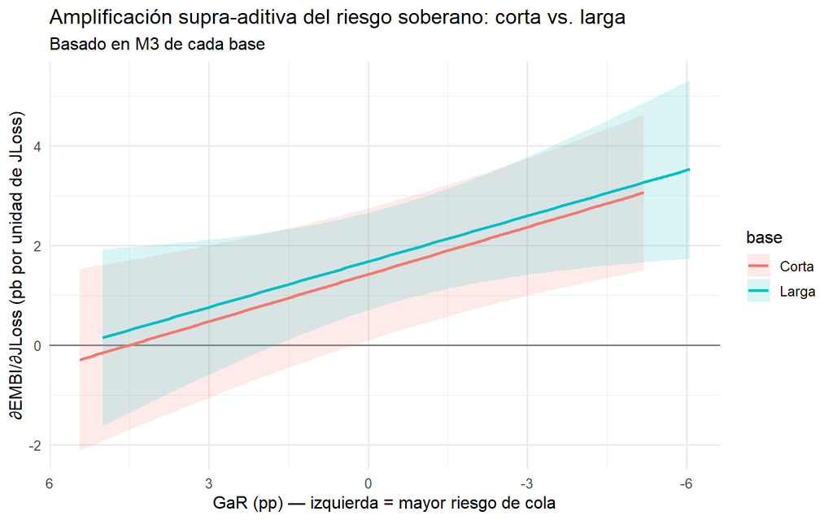

```r
marginal_df <- function(m, dat) {
  V  <- DK(m); b <- coef(m)
  bJ <- b["JLoss_c"]; bI <- b["JxG_c"]
  vJ <- V["JLoss_c","JLoss_c"]; vI <- V["JxG_c","JxG_c"]; cJI <- V["JLoss_c","JxG_c"]
  mu <- mean(dat$GaR_pp, na.rm = TRUE)
  grid <- seq(quantile(dat$GaR_pp, .05, na.rm=TRUE), quantile(dat$GaR_pp, .95, na.rm=TRUE), length.out = 100)
  dev <- grid - mu
  me  <- bJ + bI * dev
  se  <- sqrt(vJ + dev^2 * vI + 2 * dev * cJI)
  data.frame(GaR = grid, me = me, lo = me - 1.96*se, hi = me + 1.96*se)
}

mdf_corta <- marginal_df(mods_corta$M3, corta) %>% mutate(base = "Corta")
mdf_larga <- marginal_df(mods_larga$M3, larga) %>% mutate(base = "Larga")
mdf <- bind_rows(mdf_corta, mdf_larga)

ggplot(mdf, aes(GaR, me, color = base, fill = base)) +
  geom_hline(yintercept = 0, color = "grey50") +
  geom_ribbon(aes(ymin = lo, ymax = hi), alpha = .15, color = NA) +
  geom_line(linewidth = 1) +
  scale_x_reverse() +
  labs(x = "GaR (pp) — izquierda = mayor riesgo de cola",
       y = "∂EMBI/∂JLoss (pb por unidad de JLoss)",
       title = "Amplificación supra-aditiva del riesgo soberano: corta vs. larga",
       subtitle = "Basado en M3 de cada base") +
  theme_minimal(base_size = 12)
```

## 3.3 Diagnósticos (corta vs. larga)

```r
diag_table <- function(m2, m3, pdat, dat) {
  cd  <- pcdtest(m2, test = "cd")
  bg  <- pbgtest(m2)
  re  <- plm(EMBI_bps ~ JLoss_c + GaR_c + JxG_c, data = pdat, model = "random", effect = "twoways")
  ha  <- phtest(m2, re)
  data.frame(
    test = c("Pesaran CD (dep. transversal)", "Wooldridge (autocorr.)", "Hausman (FE vs RE)"),
    estadistico = round(c(cd$statistic, bg$statistic, ha$statistic), 3),
    p_valor = round(c(cd$p.value, bg$p.value, ha$p.value), 4)
  )
}

dt_corta <- diag_table(mods_corta$M2, mods_corta$M3, pan_corta, corta)
dt_larga <- diag_table(mods_larga$M2, mods_larga$M3, pan_larga, larga)

kable(list(Corta = dt_corta, Larga = dt_larga)[[1]], caption = "Diagnósticos — LatAm corta") %>% kable_styling(full_width = FALSE)
```

Diagnósticos — LatAm corta

| test | estadistico | p_valor |
| --- | --- | --- |
| Pesaran CD (dep. transversal) | -4.952 | 0.0000 |
| Wooldridge (autocorr.) | 198.948 | 0.0000 |
| Hausman (FE vs RE) | 15.977 | 0.0011 |

```r
kable(list(Corta = dt_corta, Larga = dt_larga)[[2]], caption = "Diagnósticos — LatAm larga") %>% kable_styling(full_width = FALSE)
```

Diagnósticos — LatAm larga

| test | estadistico | p_valor |
| --- | --- | --- |
| Pesaran CD (dep. transversal) | -5.201 | 0.0000 |
| Wooldridge (autocorr.) | 207.227 | 0.0000 |
| Hausman (FE vs RE) | 15.912 | 0.0012 |

```r
aux_corta <- lm(EMBI_bps ~ JLoss + GaR_pp + debt_gdp + fisc_bal + res_gdp + ca_gdp + infl_yoy + reer + VIX, data = corta)
aux_larga <- lm(EMBI_bps ~ JLoss + GaR_pp + debt_gdp + fisc_bal + res_gdp + ca_gdp + infl_yoy + reer + VIX, data = larga)
cat("VIF — corta:\n"); print(round(vif(aux_corta), 2))
```

```
## VIF — corta:
```

```
##    JLoss   GaR_pp debt_gdp fisc_bal  res_gdp   ca_gdp infl_yoy     reer
##     2.32     1.89     3.33     2.84     2.57     1.42     1.85     2.09
##      VIX
##     1.19
```

```r
cat("\nVIF — larga:\n"); print(round(vif(aux_larga), 2))
```

```
##
## VIF — larga:
```

```
##    JLoss   GaR_pp debt_gdp fisc_bal  res_gdp   ca_gdp infl_yoy     reer
##     2.16     2.20     2.17     2.37     1.77     1.22     1.84     2.06
##      VIX
##     1.25
```

# 4 Sección 2 — Robustez adicional (heredada de `Regresiones_panel.Rmd`), corta vs. larga

## 4.1 Comparación de errores estándar sobre $\theta$

```r
se_compare <- function(m) {
  se_variants <- list(
    "Driscoll-Kraay" = DK(m),
    "Cluster país"   = vcovHC(m, type = "HC1", cluster = "group"),
    "Cluster tiempo" = vcovHC(m, type = "HC1", cluster = "time"),
    "Arellano (HAC)" = vcovHC(m, method = "arellano", type = "HC1")
  )
  sapply(se_variants, function(v) {
    ct <- coeftest(m, vcov = v)["JxG_c", ]
    c(coef = round(ct[1],3), se = round(ct[2],3), t = round(ct[3],2), p = round(ct[4],4))
  })
}
cat("Corta:\n"); print(t(se_compare(mods_corta$M3)))
```

```
## Corta:
```

```
##                coef.Estimate se.Std. Error t.t value p.Pr(>|t|)
## Driscoll-Kraay        -0.316         0.102     -3.09     0.0024
## Cluster país          -0.316         0.086     -3.66     0.0004
## Cluster tiempo        -0.316         0.091     -3.47     0.0007
## Arellano (HAC)        -0.316         0.086     -3.66     0.0004
```

```r
cat("\nLarga:\n"); print(t(se_compare(mods_larga$M3)))
```

```
##
## Larga:
```

```
##                coef.Estimate se.Std. Error t.t value p.Pr(>|t|)
## Driscoll-Kraay        -0.305         0.138     -2.21     0.0282
## Cluster país          -0.305         0.103     -2.96     0.0035
## Cluster tiempo        -0.305         0.123     -2.49     0.0137
## Arellano (HAC)        -0.305         0.103     -2.96     0.0035
```

## 4.2 Subperiodo sin COVID-19

```r
ctrl <- "debt_gdp + fisc_bal + res_gdp + ca_gdp + infl_yoy + reer"
nc_model <- function(dat) {
  pdat <- pdata.frame(subset(dat, post2020 == 0), index = c("country","tnum"))
  plm(as.formula(paste("EMBI_bps ~ JLoss_c + GaR_c + JxG_c +", ctrl)),
      data = pdat, model = "within", effect = "twoways")
}
m_nc_corta <- nc_model(corta); m_nc_larga <- nc_model(larga)
cat("Corta, sin COVID:\n"); print(coeftest(m_nc_corta, vcov = DK(m_nc_corta)))
```

```
## Corta, sin COVID:
```

```
##
## t test of coefficients:
##
##           Estimate Std. Error t value    Pr(>|t|)
## JLoss_c   0.083273   0.592068  0.1406    0.888410
## GaR_c     1.515790   1.582855  0.9576    0.340388
## JxG_c    -0.255023   0.080375 -3.1729    0.001966 **
## debt_gdp -0.683167   0.593613 -1.1509    0.252331
## fisc_bal  7.166109   2.604250  2.7517    0.006955 **
## res_gdp   5.864475   2.261441  2.5932    0.010825 *
## ca_gdp   19.019193   8.650679  2.1986    0.030041 *
## infl_yoy  1.421933   3.184208  0.4466    0.656088
## reer     -1.788367   0.347628 -5.1445 0.000001208 ***
## ---
## Signif. codes:  0 '***' 0.001 '**' 0.01 '*' 0.05 '.' 0.1 ' ' 1
```

```r
cat("\nLarga, sin COVID:\n"); print(coeftest(m_nc_larga, vcov = DK(m_nc_larga)))
```

```
##
## Larga, sin COVID:
```

```
##
## t test of coefficients:
##
##           Estimate Std. Error t value      Pr(>|t|)
## JLoss_c   0.760305   0.431313  1.7628     0.0799629 .
## GaR_c    -1.248595   2.048996 -0.6094     0.5431956
## JxG_c    -0.382555   0.113656 -3.3659     0.0009676 ***
## debt_gdp  0.042542   0.536599  0.0793     0.9369139
## fisc_bal  5.192980   2.406412  2.1580     0.0325105 *
## res_gdp   1.110118   1.609891  0.6896     0.4915287
## ca_gdp    1.224633   3.012362  0.4065     0.6849247
## infl_yoy -0.588854   2.593222 -0.2271     0.8206733
## reer     -1.522146   0.256447 -5.9355 0.00000001931 ***
## ---
## Signif. codes:  0 '***' 0.001 '**' 0.01 '*' 0.05 '.' 0.1 ' ' 1
```

## 4.3 Persistencia (especificación dinámica, diagnóstico — sesgo de Nickell)

```r
dyn_model <- function(dat) {
  dat$EMBI_lag <- ave(dat$EMBI_bps, dat$country, FUN = function(x) c(NA, head(x, -1)))
  pdat <- pdata.frame(dat, index = c("country","tnum"))
  plm(as.formula(paste("EMBI_bps ~ EMBI_lag + JLoss_c + GaR_c + JxG_c +", ctrl)),
      data = pdat, model = "within", effect = "twoways")
}
m_dyn_corta <- dyn_model(corta); m_dyn_larga <- dyn_model(larga)
cat("Corta:\n"); print(coeftest(m_dyn_corta, vcov = DK(m_dyn_corta)))
```

```
## Corta:
```

```
##
## t test of coefficients:
##
##           Estimate Std. Error t value              Pr(>|t|)
## EMBI_lag  0.850218   0.060379 14.0813 < 0.00000000000000022 ***
## JLoss_c   0.118471   0.426164  0.2780             0.7814458
## GaR_c    -0.092282   1.070888 -0.0862             0.9314572
## JxG_c    -0.120240   0.070766 -1.6991             0.0916149 .
## debt_gdp -1.039846   0.269202 -3.8627             0.0001739 ***
## fisc_bal -0.176194   1.712248 -0.1029             0.9181946
## res_gdp  -0.743120   1.347074 -0.5517             0.5821035
## ca_gdp   -1.683395   2.357976 -0.7139             0.4765212
## infl_yoy -2.759741   1.942798 -1.4205             0.1577853
## reer     -0.658900   0.158242 -4.1639            0.00005568 ***
## ---
## Signif. codes:  0 '***' 0.001 '**' 0.01 '*' 0.05 '.' 0.1 ' ' 1
```

```r
cat("\nLarga:\n"); print(coeftest(m_dyn_larga, vcov = DK(m_dyn_larga)))
```

```
##
## Larga:
```

```
##
## t test of coefficients:
##
##           Estimate Std. Error t value              Pr(>|t|)
## EMBI_lag  0.851369   0.049069 17.3505 < 0.00000000000000022 ***
## JLoss_c   0.176015   0.296584  0.5935               0.55358
## GaR_c    -0.410304   0.764844 -0.5365               0.59228
## JxG_c    -0.105005   0.072961 -1.4392               0.15176
## debt_gdp -1.094347   0.236441 -4.6284          0.0000068534 ***
## fisc_bal -0.436054   1.541974 -0.2828               0.77765
## res_gdp  -0.161457   0.702322 -0.2299               0.81843
## ca_gdp   -1.131643   0.702726 -1.6104               0.10900
## infl_yoy -2.821133   1.541277 -1.8304               0.06878 .
## reer     -0.639080   0.116420 -5.4894          0.0000001293 ***
## ---
## Signif. codes:  0 '***' 0.001 '**' 0.01 '*' 0.05 '.' 0.1 ' ' 1
```

# 5 Sección 3 — Batería agrupado→FE (Tablas A/B del documento original), corta vs. larga

```r
run_battery <- function(pdat) {
  list(
    "(1) Solo JLoss"          = plm(EMBI_bps ~ JLoss_c,                  pdat, model = "pooling"),
    "(2) Solo GaR"            = plm(EMBI_bps ~ GaR_c,                    pdat, model = "pooling"),
    "(3) JLoss + GaR"         = plm(EMBI_bps ~ JLoss_c + GaR_c,          pdat, model = "pooling"),
    "(4) + interac. (sin FE)" = plm(EMBI_bps ~ JLoss_c + GaR_c + JxG_c,  pdat, model = "pooling"),
    "(5) FE país"             = plm(EMBI_bps ~ JLoss_c + GaR_c + JxG_c,  pdat, model = "within", effect = "individual"),
    "(6) FE tiempo"           = plm(EMBI_bps ~ JLoss_c + GaR_c + JxG_c,  pdat, model = "within", effect = "time"),
    "(7) FE país + tiempo"    = plm(EMBI_bps ~ JLoss_c + GaR_c + JxG_c,  pdat, model = "within", effect = "twoways")
  )
}
opts <- list(coef_map = c("JLoss_c"="JLoss","GaR_c"="GaR (pp)","JxG_c"="JLoss × GaR"),
             stars = c('*'=.1,'**'=.05,'***'=.01), gof_omit = "AIC|BIC|Log.Lik|RMSE|Adj")

bat_corta <- run_battery(pan_corta)
bat_larga <- run_battery(pan_larga)
```

```r
bat_todos <- c(setNames(bat_corta, paste0("Corta ", names(bat_corta))),
               setNames(bat_larga, paste0("Larga ", names(bat_larga))))
modelsummary(bat_todos, vcov = lapply(bat_todos, DK),
  coef_map = opts$coef_map, stars = opts$stars, gof_omit = opts$gof_omit,
  title = "Tabla 2. Del modelo agrupado a los efectos fijos — corta vs. larga")
```

Tabla 2. Del modelo agrupado a los efectos fijos — corta vs. larga

|  | Corta (1) Solo JLoss | Corta (2) Solo GaR | Corta (3) JLoss + GaR | Corta (4) + interac. (sin FE) | Corta (5) FE país | Corta (6) FE tiempo | Corta (7) FE país + tiempo | Larga (1) Solo JLoss | Larga (2) Solo GaR | Larga (3) JLoss + GaR | Larga (4) + interac. (sin FE) | Larga (5) FE país | Larga (6) FE tiempo | Larga (7) FE país + tiempo |
| --- | --- | --- | --- | --- | --- | --- | --- | --- | --- | --- | --- | --- | --- | --- |
| JLoss | 3.983*** |  | 2.802*** | 2.073*** | 0.907 | 1.833*** | 1.233*** | 4.356*** |  | 3.119*** | 2.589*** | 1.318 | 2.236*** | 1.271*** |
|  | (0.632) |  | (0.544) | (0.590) | (0.800) | (0.570) | (0.427) | (0.730) |  | (0.591) | (0.755) | (0.825) | (0.528) | (0.464) |
| GaR (pp) |  | -10.159*** | -8.310*** | -8.658*** | -7.428*** | -9.838*** | 2.863 |  | -12.330*** | -10.545*** | -10.770*** | -9.443*** | -10.297*** | 1.558 |
|  |  | (1.521) | (1.005) | (0.945) | (1.153) | (2.728) | (2.086) |  | (2.470) | (1.887) | (1.902) | (1.856) | (2.927) | (2.615) |
| JLoss × GaR |  |  |  | -0.201 | -0.380*** | -0.115 | -0.352*** |  |  |  | -0.199 | -0.405** | -0.043 | -0.336*** |
|  |  |  |  | (0.159) | (0.139) | (0.117) | (0.089) |  |  |  | (0.196) | (0.190) | (0.133) | (0.120) |
| Num.Obs. | 248 | 248 | 248 | 248 | 248 | 248 | 248 | 293 | 281 | 281 | 281 | 281 | 281 | 281 |
| R2 | 0.199 | 0.279 | 0.368 | 0.372 | 0.323 | 0.278 | 0.165 | 0.174 | 0.316 | 0.404 | 0.406 | 0.341 | 0.283 | 0.116 |
| Std.Errors | Corta (1) Solo JLoss | Corta (2) Solo GaR | Corta (3) JLoss + GaR | Corta (4) + interac. (sin FE) | Corta (5) FE país | Corta (6) FE tiempo | Corta (7) FE país + tiempo | Larga (1) Solo JLoss | Larga (2) Solo GaR | Larga (3) JLoss + GaR | Larga (4) + interac. (sin FE) | Larga (5) FE país | Larga (6) FE tiempo | Larga (7) FE país + tiempo |

* p < 0.1, ** p < 0.05, *** p < 0.01

# 6 Sección 3bis — Controles del paper de JLoss como índice agregado $X_{i,t}$

Los controles adicionales que replican los del paper de referencia de JLoss (Chari et al., 2024) — `debt_gdp` (log), `profit_margin`, `UST10Y` (log), `US_HY_spread` (log) y `OnOffRun_spread` (log) — se incorporan como **un índice agregado** en vez de seis regresores sueltos, por dos razones: (i) `profit_margin` solo tiene cobertura real en 2007-2011 (ver más abajo) y (ii) meter seis controles correlacionados entre sí en un panel de *N* moderado infla varianza sin ganar identificación.

**`US_HY_spread` queda fuera del índice**: el proxy (`BAMLH0A0HYM2`, ICE BofA US HY OAS) llegó sin cobertura en la ventana de estudio (2004-2022) — la serie descargada solo trae observaciones desde 2023Q3, así que se excluye hasta resolver la descarga. **Exchange-rate volatility también queda fuera** (pendiente, sin fuente construida todavía).

## 6.1 Por qué el índice se separa en dos: doméstico vs. global

Un solo índice mezclando `debt_gdp`/`profit_margin` (varían por país-trimestre) con `UST10Y`/`OnOffRun_spread` (varían solo por trimestre, iguales para los 5-11 países en cada fecha) es econométricamente incómodo bajo **efectos fijos de tiempo**: la parte puramente global de la mezcla queda absorbida casi por completo por esos efectos de tiempo, y el índice combinado pierde poder de forma artificial (se probó: con FE país+tiempo el índice combinado no fue significativo en ninguna base, con $R^2$ *within* incluso negativo en la corta — síntoma de que se estaba pidiendo identificar variación que ya no existía tras demediar por tiempo). La solución estándar es la misma que ya usa `M5` en la Sección 1: separar el control global y estimarlo con **FE de país únicamente** (sin FE de tiempo), dejando el componente doméstico donde sí corresponde, con FE país+tiempo.

- **`X_dom_idx`** = promedio de z-scores de `debt_gdp_log` y `profit_margin` (los que sí varían por país). Se usa con **FE país+tiempo**, igual que el resto de la batería principal.
- **`X_global_idx`** = promedio de z-scores de `UST10Y_log` y `OnOffRun_spread_log` (comunes a todos los países cada trimestre). Se usa con **FE país únicamente**, igual que `M5`.

```r
idx_cov <- bind_rows(
  corta     %>% mutate(base = "1. LatAm corta"),
  larga     %>% mutate(base = "2. LatAm larga"),
  extendida %>% mutate(base = "3. Extendida 15 países")
) %>%
  group_by(base) %>%
  summarise(n = n(),
            X_dom_idx_valido = sum(!is.na(X_dom_idx)),
            X_global_idx_valido = sum(!is.na(X_global_idx)), .groups = "drop")
kable(idx_cov, caption = "Cobertura de los índices agregados por base") %>%
  kable_styling(full_width = FALSE)
```

Cobertura de los índices agregados por base

base

n

X_dom_idx_valido

X_global_idx_valido

1. LatAm corta

248

206

248

2. LatAm larga

293

286

293

3. Extendida 15 países

395

95

395

```r
idx_model_dom <- function(dat) {
  d <- subset(dat, !is.na(X_dom_idx))
  pdat <- pdata.frame(d, index = c("country", "tnum"))
  plm(EMBI_bps ~ JLoss_c + GaR_c + JxG_c + X_dom_idx, data = pdat,
      model = "within", effect = "twoways")
}
idx_model_glob <- function(dat) {
  d <- subset(dat, !is.na(X_global_idx))
  pdat <- pdata.frame(d, index = c("country", "tnum"))
  plm(EMBI_bps ~ JLoss_c + GaR_c + JxG_c + X_global_idx, data = pdat,
      model = "within", effect = "individual")
}

M_dom_corta  <- idx_model_dom(corta);      M_dom_larga  <- idx_model_dom(larga)
M_glob_corta <- idx_model_glob(corta);     M_glob_larga <- idx_model_glob(larga)
M_glob_ext   <- idx_model_glob(extendida)  # X_dom_idx en extendida cae a n=83 (solo LatAm 2007-2011); se omite de la tabla principal

mods_idx <- list(
  "Corta, X_dom (FE2)"       = M_dom_corta,
  "Larga, X_dom (FE2)"       = M_dom_larga,
  "Corta, X_global (FE país)"  = M_glob_corta,
  "Larga, X_global (FE país)"  = M_glob_larga,
  "Extendida, X_global (FE país)" = M_glob_ext
)
modelsummary(mods_idx, vcov = lapply(mods_idx, DK),
  coef_map = c("JLoss_c"="JLoss", "GaR_c"="GaR (pp)", "JxG_c"="JLoss × GaR",
               "X_dom_idx"="Índice doméstico (paper)", "X_global_idx"="Índice global (paper)"),
  stars = c('*'=.1,'**'=.05,'***'=.01), gof_omit = "AIC|BIC|Log.Lik|RMSE|Adj",
  notes = "SE Driscoll-Kraay. X_dom: FE país+tiempo. X_global: FE país (ver texto).",
  title = "Tabla 2bis. θ con los controles del paper de JLoss como índice agregado")
```

Tabla 2bis. θ con los controles del paper de JLoss como índice agregado

|  | Corta, X_dom (FE2) | Larga, X_dom (FE2) | Corta, X_global (FE país) | Larga, X_global (FE país) | Extendida, X_global (FE país) |
| --- | --- | --- | --- | --- | --- |
| JLoss | 1.866*** | 1.455*** | 1.066 | 1.643** | 2.405*** |
|  | (0.540) | (0.447) | (0.730) | (0.690) | (0.867) |
| GaR (pp) | 3.494 | 1.180 | -7.067*** | -5.118*** | -5.141*** |
|  | (2.447) | (2.521) | (1.008) | (1.647) | (1.616) |
| JLoss × GaR | -0.306*** | -0.327*** | -0.358*** | -0.391** | -0.157 |
|  | (0.093) | (0.114) | (0.133) | (0.169) | (0.174) |
| Índice doméstico (paper) | -46.674 | -16.274 |  |  |  |
|  | (31.858) | (12.285) |  |  |  |
| Índice global (paper) |  |  | -13.949 | -62.191*** | -57.288*** |
|  |  |  | (9.592) | (20.915) | (17.964) |
| Num.Obs. | 206 | 280 | 248 | 281 | 374 |
| R2 | 0.287 | 0.146 | 0.334 | 0.464 | 0.412 |
| Std.Errors | Corta, X_dom (FE2) | Larga, X_dom (FE2) | Corta, X_global (FE país) | Larga, X_global (FE país) | Extendida, X_global (FE país) |

* p < 0.1, ** p < 0.05, *** p < 0.01  
SE Driscoll-Kraay. X_dom: FE país+tiempo. X_global: FE país (ver texto).